# `mice`: multivariate imputation by chained equations

Becki Green

13/04/2021

### Background

Multiple imputation refers to the method of replacing missing values multiple times, generating multiple datasets. Multivariate imputation by chained equations (mice) is a type of multiple imputation, which replaces these missing values using a chain of regression equations. Missing values are replaced one-by-one, using information from other variables, which are the predictors in these regression models. Residual error is added in order to add some variability to each of the imputations.

Analyses can then be performed on each of these imputed datasets and the coefficients and standard errors can be pooled into one set of results. Using multiple versions of this missing data can lead to less biased and thus more accurate analyses.

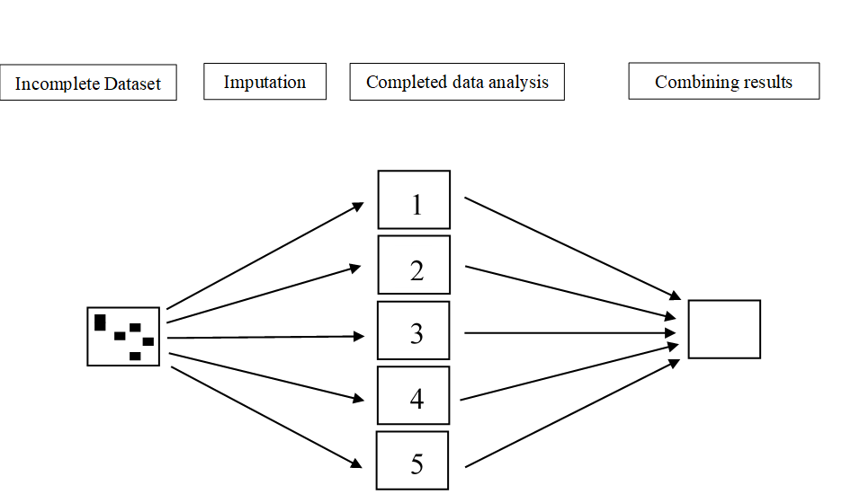

From: [Applied Missing Data Analysis with SPSS & RStudio, Heymans & Eekhourt, 2019](https://bookdown.org/mwheymans/bookmi/multiple-imputation.html#multiple-imputation-in-r)

**MICE process:**

1. All missing data are replaced with the mean, or some other prescriptive method
2. One variable is set back to missing
3. This variable is regressed on the other variables in the dataset
4. Missing values are imputed using predictions from the regression model
5. 1-4 are then repeated for other variables with missing data
6. Once all missing data is imputed, 1-5 are then repeated again until convergence is met
7. Then 1-6 are repeated for each new dataset!

### 1) Loading packages

```r
#install.packages("pacman")
pacman::p_load(mice, Hmisc)
```

### 2) Loading in and inspecting data

```r
df <- iris #load in data
describe(df) #quick glance - looks sensible
```

```
## df
##
##  5  Variables      150  Observations
## --------------------------------------------------------------------------------
## Sepal.Length
##        n  missing distinct     Info     Mean      Gmd      .05      .10
##      150        0       35    0.998    5.843   0.9462    4.600    4.800
##      .25      .50      .75      .90      .95
##    5.100    5.800    6.400    6.900    7.255
##
## lowest : 4.3 4.4 4.5 4.6 4.7, highest: 7.3 7.4 7.6 7.7 7.9
## --------------------------------------------------------------------------------
## Sepal.Width
##        n  missing distinct     Info     Mean      Gmd      .05      .10
##      150        0       23    0.992    3.057   0.4872    2.345    2.500
##      .25      .50      .75      .90      .95
##    2.800    3.000    3.300    3.610    3.800
##
## lowest : 2.0 2.2 2.3 2.4 2.5, highest: 3.9 4.0 4.1 4.2 4.4
## --------------------------------------------------------------------------------
## Petal.Length
##        n  missing distinct     Info     Mean      Gmd      .05      .10
##      150        0       43    0.998    3.758    1.979     1.30     1.40
##      .25      .50      .75      .90      .95
##     1.60     4.35     5.10     5.80     6.10
##
## lowest : 1.0 1.1 1.2 1.3 1.4, highest: 6.3 6.4 6.6 6.7 6.9
## --------------------------------------------------------------------------------
## Petal.Width
##        n  missing distinct     Info     Mean      Gmd      .05      .10
##      150        0       22     0.99    1.199   0.8676      0.2      0.2
##      .25      .50      .75      .90      .95
##      0.3      1.3      1.8      2.2      2.3
##
## lowest : 0.1 0.2 0.3 0.4 0.5, highest: 2.1 2.2 2.3 2.4 2.5
## --------------------------------------------------------------------------------
## Species
##        n  missing distinct
##      150        0        3
##
## Value          setosa versicolor  virginica
## Frequency          50         50         50
## Proportion      0.333      0.333      0.333
## --------------------------------------------------------------------------------
```

```r
sapply(df, class) #checking classes - looks correct, no need to transform
```

```
## Sepal.Length  Sepal.Width Petal.Length  Petal.Width      Species
##    "numeric"    "numeric"    "numeric"    "numeric"     "factor"
```